# A worked `transitiontrees` example: AI-prompting move sequences

This is a short, end-to-end analysis of one real dataset — **not** a tour of every function. The data are sequences of *rhetorical moves* students make while prompting an LLM (`Order`, `Specify`, `Context`, `Reject`, `Request`, `Approve`); one **prompt** is one sequence. The question throughout: *after a given short history of moves, what does a student do next, and which contexts overturn the corpus-wide default?*

# 1. Load and fit

`context_tree()` reads the long event log directly — give it the sequence id (`actor`), the event column (`action`), and the within-sequence order (`order`); it reshapes internally (no `Nestimate`/`prepare_input()` step needed). Prompts are short, so the deepest context worth asking for is 3 moves; with only a few hundred prompts we keep `min_count` low.

```r
raw <- read.csv(
  "/Users/mohammedsaqr/Documents/Documents X/DocumentsX/TNA Work/TNA networks teem data/Seqdatalonged.csv",
  stringsAsFactors = FALSE)

tree <- context_tree(
  raw,
  actor     = "prompt_id",   # one prompt = one sequence
  action    = "name",        # the move
  order     = "value",       # move order within a prompt
  max_depth = 3L,            # longest context the tree may hold
  min_count = 3L             # a context needs >= 3 occurrences to get a node
)
tree
```

```
## <transitiontrees>  24 nodes, depth <= 3, 6 states  [unpruned]
##   alphabet : Approve, Context, Order, Reject, Request, Specify
##   fit on   : 281 sequences, 726 observations
##   smoothing: floor(ymin=0.001, rule=interpolate)   min_count = 3
## (start)   n=726    -> Order (0.34)
## |-- Approve   n=13     -> Order (0.77)
## |-- Context   n=87     -> Specify (0.89)
## |   |-- Order     n=74     -> Specify (0.98)
## |   |   `-- Request   n=4      -> Specify (0.99)
## |   `-- Specify   n=3      -> Order (0.66)
## |-- Order     n=194    -> Specify (0.55)
## |   |-- Approve   n=10     -> Specify (0.80)
## |   |-- Context   n=3      -> Request (0.66)
## |   |-- Reject    n=14     -> Specify (0.92)
## |   `-- Request   n=17     -> Specify (0.76)
## |       `-- Reject    n=4      -> Specify (0.99)
## |-- Reject    n=56     -> Specify (0.55)
## |   `-- Request   n=3      -> Order (0.99)
## |-- Request   n=32     -> Order (0.75)
## |   |-- Context   n=3      -> Order (0.66)
## |   |-- Order     n=3      -> Specify (0.99)
## |   `-- Reject    n=5      -> Order (0.99)
## `-- Specify   n=63     -> Request (0.38)
##     |-- Context   n=18     -> Request (0.77)
##     |   `-- Order     n=14     -> Request (0.99)
##     |-- Order     n=24     -> Context (0.71)
##     |   `-- Request   n=4      -> Context (0.99)
##     `-- Reject    n=9      -> Order (0.77)
```

# 2. Inspect the model

The print banner gives depth, node count, and the corpus size. `summary()` adds the per-depth breakdown, and `model_fit()` bundles the goodness-of-fit scalars (`logLik`, `df`, `nobs`, `AIC`, `BIC`, `perplexity`) into one row.

```r
summary(tree)
```

```
## <transitiontrees summary>  24 nodes, depth <= 3, 6 states  [unpruned]
##
##             pathway depth count likely_next next_probability divergence
##             (start)     0   726       Order        0.3429752         NA
##               Order     1   194     Specify        0.5492371  0.8816161
##             Context     1    87     Specify        0.8921724  1.0746190
##             Specify     1    63     Request        0.3796667  1.1101873
##              Reject     1    56     Specify        0.5512500  0.4331304
##             Request     1    32       Order        0.7465000  0.6738563
##             Approve     1    13       Order        0.7656154  0.6988270
##    Order -> Context     2    74     Specify        0.9815676  0.1104970
##    Order -> Specify     2    24     Context        0.7050833  0.5941452
##  Context -> Specify     2    18     Request        0.7741111  0.7405598
##  changes_prediction
##                  NA
##                TRUE
##                TRUE
##                TRUE
##                TRUE
##               FALSE
##               FALSE
##               FALSE
##                TRUE
##               FALSE
## # ... 14 more rows (use as.data.frame(tree) for the full table)
```

```r
model_fit(tree)
```

| logLik | df | nobs | AIC | BIC | perplexity |
| --- | --- | --- | --- | --- | --- |
| -736.198 | 120 | 726 | 1712.396 | 2262.902 | 2.756734 |

The in-sample **perplexity** of 2.76 says the fitted tree is, on average, as uncertain as a fair choice among that many moves — well below the 6-move uniform baseline, so history is genuinely informative.

# 3. Pathway tables

The pathway-centric API returns plain `data.frame`s in one canonical schema (`pathway | depth | count | likely_next | next_probability | divergence | changes_prediction`), so every view joins cleanly. Three named verbs each fix a useful sort:

```r
common_pathways(tree, top = 8)      # by frequency: the backbone
```

|  | pathway | depth | count | likely_next | next_probability | divergence | changes_prediction |
| --- | --- | --- | --- | --- | --- | --- | --- |
| 1 | (start) | 0 | 726 | Order | 0.3429752 | NA | NA |
| 2 | Order | 1 | 194 | Specify | 0.5492371 | 0.8816161 | TRUE |
| 3 | Context | 1 | 87 | Specify | 0.8921724 | 1.0746190 | TRUE |
| 4 | Order -> Context | 2 | 74 | Specify | 0.9815676 | 0.1104970 | FALSE |
| 5 | Specify | 1 | 63 | Request | 0.3796667 | 1.1101873 | TRUE |
| 6 | Reject | 1 | 56 | Specify | 0.5512500 | 0.4331304 | TRUE |
| 7 | Request | 1 | 32 | Order | 0.7465000 | 0.6738563 | FALSE |
| 8 | Order -> Specify | 2 | 24 | Context | 0.7050833 | 0.5941452 | TRUE |

```r
divergent_pathways(tree, top = 8)   # by KL from the shorter history
```

|  | pathway | depth | count | likely_next | next_probability | divergence | changes_prediction |
| --- | --- | --- | --- | --- | --- | --- | --- |
| 1 | Specify -> Context | 2 | 3 | Order | 0.6636667 | 3.2253597 | TRUE |
| 2 | Context -> Order | 2 | 3 | Request | 0.6636667 | 2.6572760 | TRUE |
| 3 | Order -> Request | 2 | 3 | Specify | 0.9950000 | 2.6408106 | TRUE |
| 4 | Request -> Reject | 2 | 3 | Order | 0.9950000 | 1.4598108 | TRUE |
| 5 | Specify | 1 | 63 | Request | 0.3796667 | 1.1101873 | TRUE |
| 6 | Context | 1 | 87 | Specify | 0.8921724 | 1.0746190 | TRUE |
| 7 | Reject -> Specify | 2 | 9 | Order | 0.7741111 | 1.0625406 | TRUE |
| 8 | Order | 1 | 194 | Specify | 0.5492371 | 0.8816161 | TRUE |

```r
sharp_pathways(tree, top = 8)       # by how peaked the next-move prediction is
```

|  | pathway | depth | count | likely_next | next_probability | divergence | changes_prediction |
| --- | --- | --- | --- | --- | --- | --- | --- |
| 1 | Order -> Context -> Specify | 3 | 14 | Request | 0.9950000 | 0.35255140 | FALSE |
| 2 | Reject -> Request | 2 | 5 | Order | 0.9950000 | 0.39863574 | FALSE |
| 3 | Reject -> Request -> Order | 3 | 4 | Specify | 0.9950000 | 0.37676838 | FALSE |
| 4 | Request -> Order -> Context | 3 | 4 | Specify | 0.9950000 | 0.01565966 | FALSE |
| 5 | Request -> Order -> Specify | 3 | 4 | Context | 0.9950000 | 0.48623377 | FALSE |
| 6 | Request -> Reject | 2 | 3 | Order | 0.9950000 | 1.45981079 | TRUE |
| 7 | Order -> Request | 2 | 3 | Specify | 0.9950000 | 2.64081059 | TRUE |
| 8 | Order -> Context | 2 | 74 | Specify | 0.9815676 | 0.11049698 | FALSE |

`common_pathways()` is the backbone (what students mostly do). `divergent_pathways()` surfaces the contexts where a longer history *changes* the prediction — `changes_prediction = TRUE` flags a modal-move flip. Those are the interesting rows: places where knowing the previous move(s) overturns the corpus default.

# 4. Per-context diagnostics

`tree_dependence()` quantifies, per context, how much the history sharpens the next-move distribution — `entropy_drop` is the reduction in predictive entropy (bits) the context buys over its shorter suffix.

```r
dep <- tree_dependence(tree)
head(dep[order(-dep$entropy_drop),
         c("pathway", "depth", "count", "entropy_drop",
           "likely_before", "likely_next", "changes_prediction")], 8)
```

|  | pathway | depth | count | entropy_drop | likely_before | likely_next | changes_prediction |
| --- | --- | --- | --- | --- | --- | --- | --- |
| 6 | Context | 1 | 87 | 1.5442465 | Order | Specify | TRUE |
| 4 | Request -> Reject | 2 | 3 | 1.2891224 | Specify | Order | TRUE |
| 11 | Approve | 1 | 13 | 1.1323860 | Order | Order | FALSE |
| 12 | Request | 1 | 32 | 1.0743849 | Order | Order | FALSE |
| 3 | Order -> Request | 2 | 3 | 1.0272833 | Order | Specify | TRUE |
| 16 | Reject -> Request | 2 | 5 | 1.0272833 | Order | Order | FALSE |
| 8 | Order | 1 | 194 | 0.8801333 | Order | Specify | TRUE |
| 7 | Reject -> Specify | 2 | 9 | 0.8734137 | Request | Order | TRUE |

# 5. Prune to the reliable tree

A context that survives fitting can still be over-fit. `prune_tree()` collapses contexts whose extra depth does not buy a statistically significant gain over their parent (default: a likelihood-ratio test at `alpha = 0.05`).

```r
pruned <- prune_tree(tree, criterion = "G2", alpha = 0.05)
pruned
```

```
## <transitiontrees>  15 nodes, depth <= 3, 6 states  [pruned]
##   alphabet : Approve, Context, Order, Reject, Request, Specify
##   fit on   : 281 sequences, 726 observations
##   smoothing: floor(ymin=0.001, rule=interpolate)   min_count = 3
##   pruned by: G2   alpha = 0.05
## (start)   n=726    -> Order (0.34)
## |-- Approve   n=13     -> Order (0.77)
## |-- Context   n=87     -> Specify (0.89)
## |   |-- Order     n=74     -> Specify (0.98)
## |   `-- Specify   n=3      -> Order (0.66)
## |-- Order     n=194    -> Specify (0.55)
## |   |-- Context   n=3      -> Request (0.66)
## |   `-- Reject    n=14     -> Specify (0.92)
## |-- Reject    n=56     -> Specify (0.55)
## |-- Request   n=32     -> Order (0.75)
## |   `-- Order     n=3      -> Specify (0.99)
## `-- Specify   n=63     -> Request (0.38)
##     |-- Context   n=18     -> Request (0.77)
##     |-- Order     n=24     -> Context (0.71)
##     `-- Reject    n=9      -> Order (0.77)
```

Pruning takes the model from 24 contexts down to 15 — the deepest, thinnest contexts that could not justify their own parameters are folded back into their parents.

# 6. Bootstrap reliability

A pathway can look informative in one dataset by chance. `bootstrap_pathways()` resamples whole prompts and asks which pathways are *reproducibly* stable (count holds within a tolerance band) **and** informative ( clears the bar in most resamples). A pathway worth a claim is **both**.

```r
boot <- bootstrap_pathways(pruned, iter = 200L, stat = "count", seed = 1L)
boot
```

```
## <transitiontrees_bootstrap>  200 resamples
##   stability  : count in [0.50, 1.50] x observed, p < 0.05
##   informative: G^2 > qchisq(0.95, df=k-1) = 11.07, threshold 0.80
##   pathways   : 15 total, 10 stable, 8 informative, 8 both
##
## top pathways (stable + informative first):
##             pathway depth count p_stability stability_rate stable
##               Order     1   194       0.005          1.000   TRUE
##             Context     1    87       0.005          1.000   TRUE
##             Specify     1    63       0.005          1.000   TRUE
##              Reject     1    56       0.005          1.000   TRUE
##             Request     1    32       0.005          1.000   TRUE
##    Order -> Specify     2    24       0.010          0.995   TRUE
##  Context -> Specify     2    18       0.035          0.970   TRUE
##     Reject -> Order     2    14       0.035          0.970   TRUE
##             (start)     0   726       0.005          1.000   TRUE
##    Order -> Context     2    74       0.005          1.000   TRUE
##  informative_rate informative mean_G2 ci_G2_lo ci_G2_hi
##             1.000        TRUE 244.675  220.616  271.873
##             1.000        TRUE 134.694  104.056  170.600
##             1.000        TRUE 100.891   74.014  127.689
##             1.000        TRUE  37.008   26.155   48.513
##             1.000        TRUE  32.695   19.352   50.240
##             0.985        TRUE  20.232   11.383   30.020
##             0.955        TRUE  18.618    9.901   26.992
##             0.905        TRUE  16.509    9.240   24.168
##                NA       FALSE     NaN       NA       NA
##             0.645       FALSE  12.898    4.558   21.689
## # ... 5 more pathways (use summary(x) for full table)
```

```r
bs <- summary(boot)
bs[bs$stable & bs$informative,
   c("pathway", "depth", "count", "likely_next", "next_probability",
     "stability_rate", "informative_rate")]
```

|  | pathway | depth | count | likely_next | next_probability | stability_rate | informative_rate |
| --- | --- | --- | --- | --- | --- | --- | --- |
| 1 | Order | 1 | 194 | Specify | 0.5515464 | 1.000 | 1.000 |
| 2 | Context | 1 | 87 | Specify | 0.8965517 | 1.000 | 1.000 |
| 3 | Specify | 1 | 63 | Request | 0.3809524 | 1.000 | 1.000 |
| 4 | Reject | 1 | 56 | Specify | 0.5535714 | 1.000 | 1.000 |
| 5 | Request | 1 | 32 | Order | 0.7500000 | 1.000 | 1.000 |
| 6 | Order -> Specify | 2 | 24 | Context | 0.7083333 | 0.995 | 0.985 |
| 7 | Context -> Specify | 2 | 18 | Request | 0.7777778 | 0.970 | 0.955 |
| 8 | Reject -> Order | 2 | 14 | Specify | 0.9285714 | 0.970 | 0.905 |

These — the single-move backbone plus the handful of depth-2 rules that clear the reproducibility bar — are the pathways you can state as findings.

# 7. Plots

A few of the package’s visual outputs on this tree.

**The tree.** Node size scales with count, edge width with transition flow; internal-node labels sit below their circles.

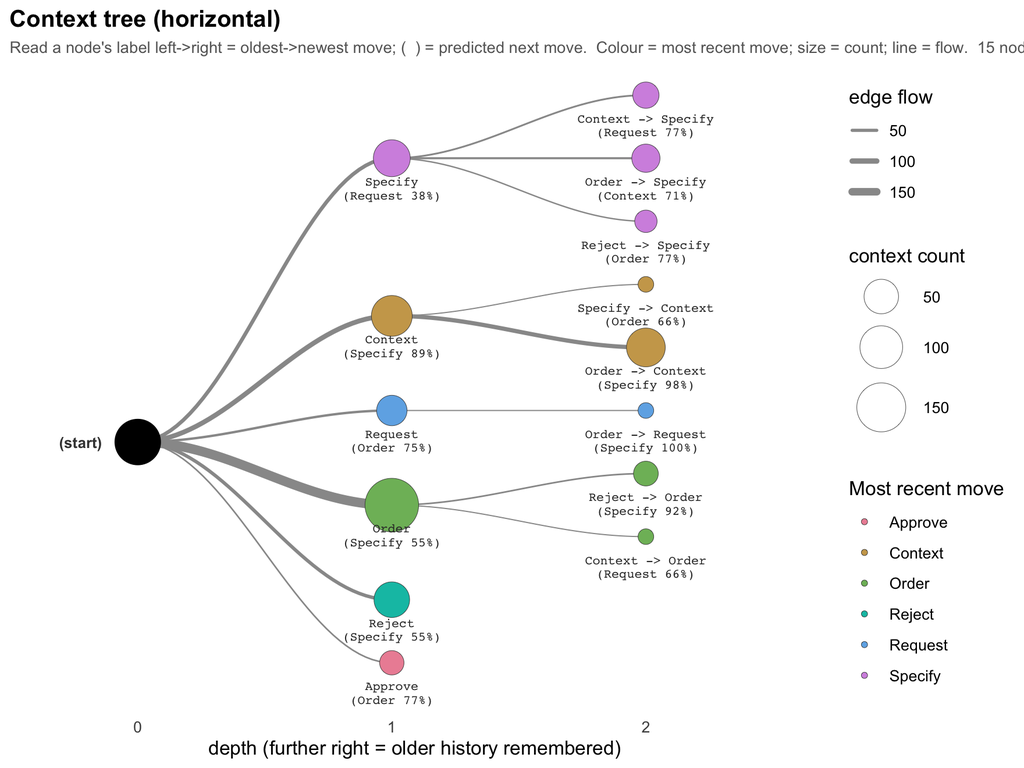

```r
plot(pruned, style = "horizontal")
```

**Pathway heatmap.** Each row is a context, each column a next move; the cell is the predicted probability, the modal cell highlighted.

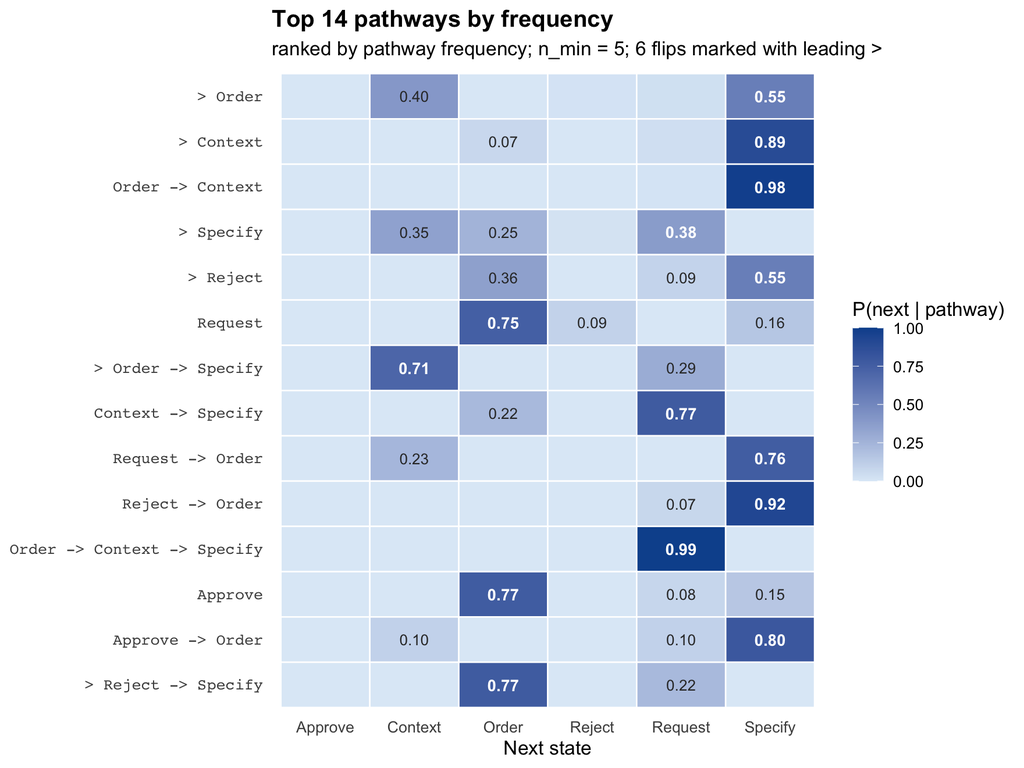

```r
plot_pathways(tree, top = 14)
```

**Divergence lollipop.** Per-context KL from the shorter history; orange marks contexts whose modal next move flips.

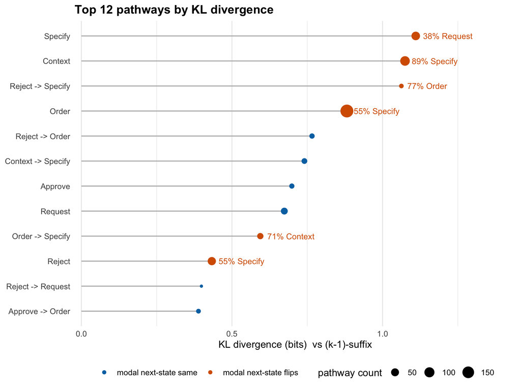

```r
plot_divergence(tree, top = 12)
```

**Bootstrap forest.** Per-pathway with bootstrap CIs; the dashed line is the critical value — pathways whose interval sits entirely to its right are reproducibly informative.

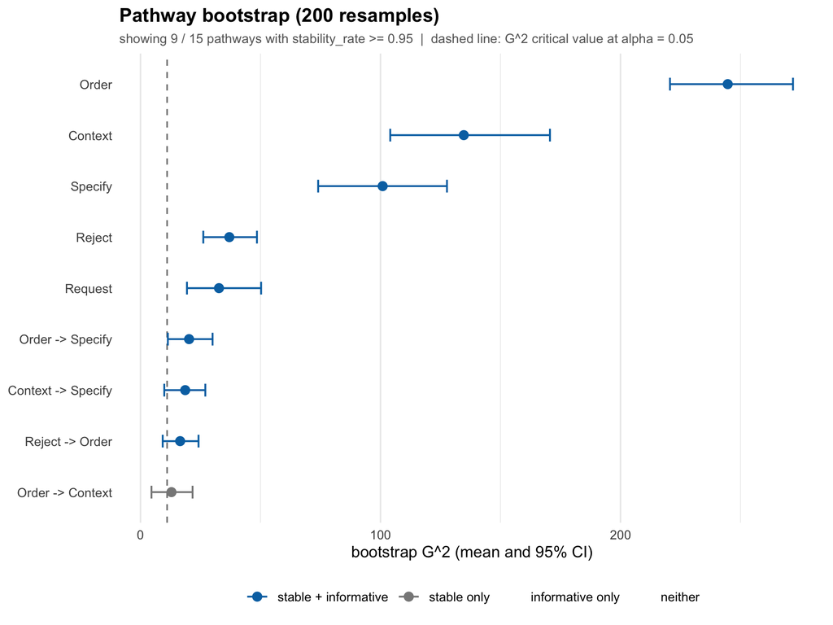

```r
plot(boot)
```

# 8. Predicting the next move

Finally, the point of the model: given a history, predict the next move and its probability.

```r
predict(tree, c("Order", "Context"), type = "class")       # most likely next
```

```
## [1] "Specify"
```

```r
predict(tree, c("Order", "Context"), type = "prob")        # full distribution
```

```
##    Approve    Context      Order     Reject    Request    Specify
## 0.00100000 0.00100000 0.00100000 0.00100000 0.01443243 0.98156757
```